# EDS 241: Assignment 1

Javier Patrón

2023-02-24

# EDS 241 Assignment 1

### Due on 2/27/23

The data for this assignment are taken from CalEnviroScreen 4.0, a mapping and data tool produced by the California Office of Environmental Health Hazards Assessment (OEHHA). The data are compiled and constructed from a variety of sources and cover all 8,035 census tracts in California. Source: https://oehha.ca.gov/calenviroscreen/report/calenviroscreen-40

The full data are contained in the file CES4.xls, which is available on Gauchospace (note that the Excel file has three “tabs” or “sheets”). The data is in the tab “CES4.0FINAL_results” and “Data Dictionary” contains the definition of the variables. For the assignment, you will need the following variables: CensusTract, TotalPopulation, LowBirthWeight (percent of census tract births with weight less than 2500g), PM25 (ambient concentrations of PM2.5 in the census tract, in micrograms per cubic meters), Poverty (percent of population in the census tract living below twice the federal poverty line), and LinguisticIsolation (percent of households in the census tract with limited English speaking).

Set the libraries

```r
library(tidyverse)
library(janitor)
library(estimatr)
library(stargazer)
library(car)
```

Read the data

```r
ces4 <- read_csv("CES4.csv") |>
  clean_names()
```

## (a) What is the average concentration of PM2.5 across all census tracts in California?

```r
mean(ces4$pm2_5)
```

```
## [1] 10.1527
```

## (b) Make a histogram depicting the distribution of percent low birth weight and PM2.5.

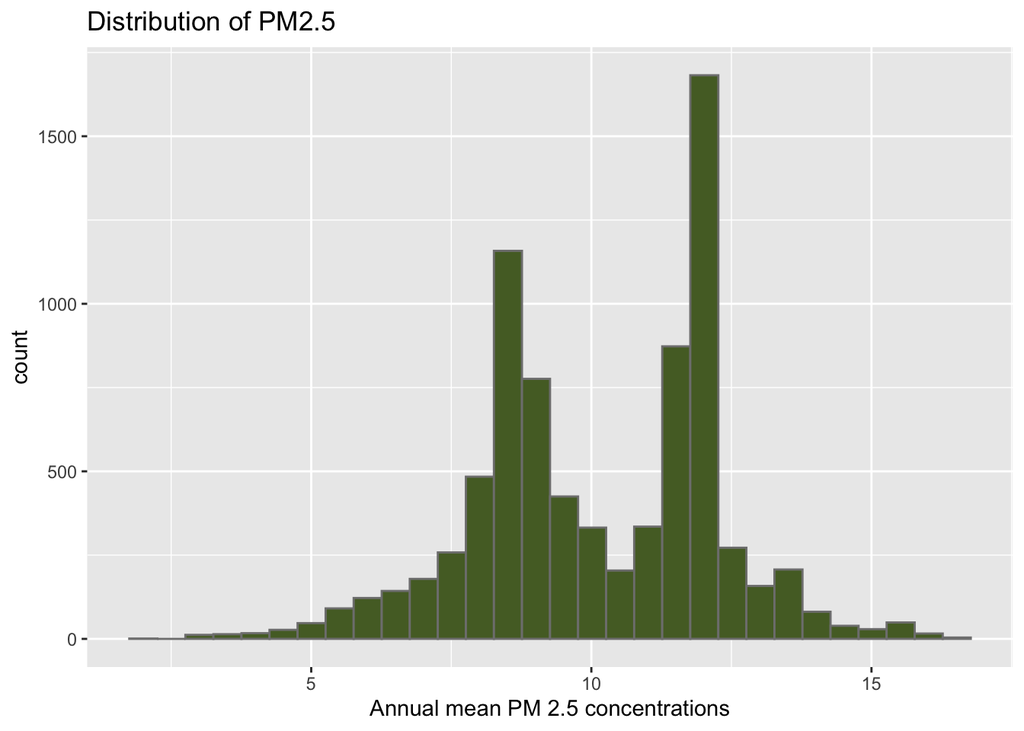

```r
ggplot(ces4, aes(x=pm2_5)) +
  geom_histogram(bins = 30, fill = "darkolivegreen" , color = "gray50") +
  labs(title = "Distribution of PM2.5",
       x = "Annual mean PM 2.5 concentrations")
```

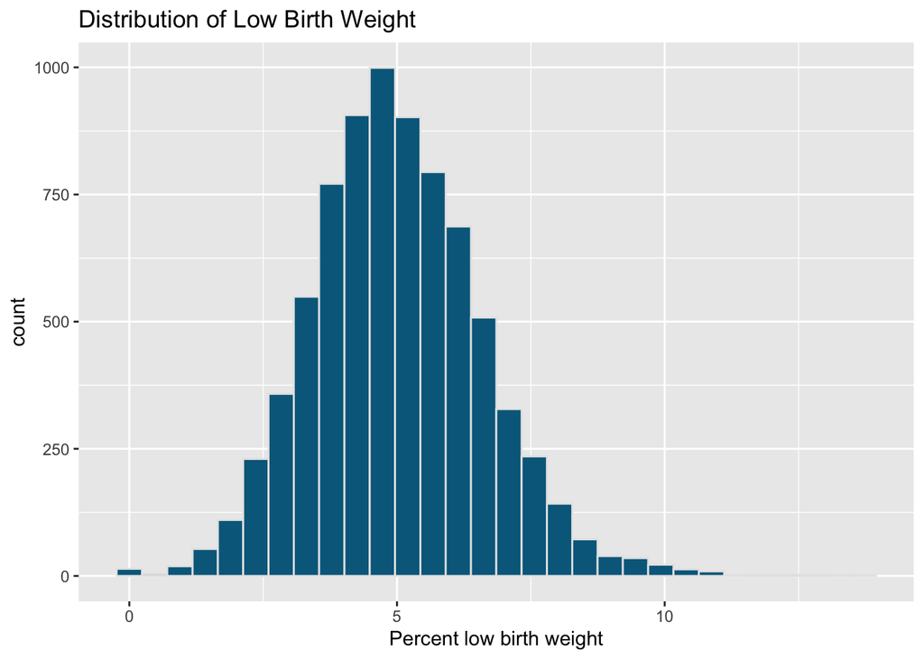

```r
ggplot(ces4, aes(x=as.numeric(low_birth_weight))) +
  geom_histogram(bins = 30, fill = "deepskyblue4", color = "gray90") +
  labs(title = "Distribution of Low Birth Weight",
      x = "Percent low birth weight")
```